# AS2018335 - P.H.U.Devindi

## Coronavirus Sri Lanka Report

```r
library(coronavirus)
library(tidyverse)
library(magrittr)
```

```r
coronavirus$cases <- abs(coronavirus$cases)
coronavirus <- as.data.frame(coronavirus, stringAsFactors = TRUE)
Sri_Lanka_Corona <- coronavirus %>% filter(country == "Sri Lanka")
library(ggplot2)
library(maptools)
library(tibble)
library(tidyverse)
library(ggrepel)
library(png)
library(grid)
library(sp)
```

## Introduction

### Location of Sri Lanka

estination Sri Lanka, an island nation in the Indian Ocean, located between the Laccadive Sea in west and the Bay of Bengal in east. The island is situated about 30 km south east of the southern coast of India.

**Sri Lanka in the world map**

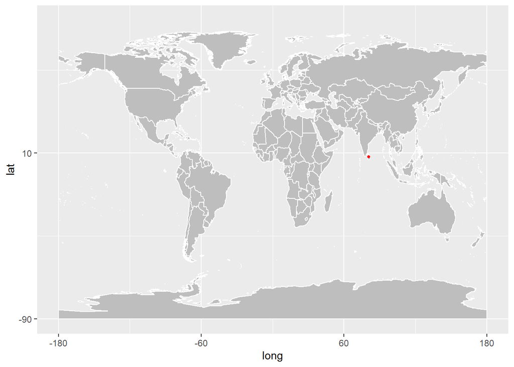

```r
data(wrld_simpl)

p <- ggplot() +
  geom_polygon(
    data = wrld_simpl,
    aes(x = long, y = lat, group = group), fill = "gray", colour = "white"
  ) +
  coord_cartesian(xlim = c(-180, 180), ylim = c(-90, 90)) +
  scale_x_continuous(breaks = seq(-180, 180, 120)) +
  scale_y_continuous(breaks = seq(-90, 90, 100))
p +
  geom_point(
    data =  Sri_Lanka_Corona , aes(x = long, y = lat), color = "red", size
    = 1
  )
```

### Climate condition in Sri Lanka

Sri Lanka’s climate is tropical and consists of distinct wet and dry seasons. Generally speaking, the coastal areas of Sri Lanka enjoy temperatures averaging 28°C (82°F) while the upland areas are cooler and more temperate, with a yearly average around 16-20°C (60-68°F).

### Lock-down status of Sri Lanka and actions tacken by the government

On March 11, 2020, the World Health Organization (WHO) declared COVID-19 a global pandemic. Sri Lanka was extremely vulnerable to the spread of the virus because of its thriving tourism industry and large expatriate population. The first case was detected on January 27, 2020 and the first Sri Lankan national tested positive for COVID-19 on March 10, 2020. In response, the Government of Sri Lanka rapidly introduced measures to curb the spread of the disease and imposed a strict island wide lockdown on March 16, 2020. After that Sri Lankan government imposed a island wide lockdown in several times. Sri Lanka is still in a island wide lockdown state.

## Exploratory Data Analysis

```r
Sri_Lanka_Corona <- as.data.frame(Sri_Lanka_Corona)
head(Sri_Lanka_Corona)
```

```
##         date province   country      lat    long      type cases
## 1 2020-01-22     <NA> Sri Lanka 7.873054 80.7718 confirmed     0
## 2 2020-01-23     <NA> Sri Lanka 7.873054 80.7718 confirmed     0
## 3 2020-01-24     <NA> Sri Lanka 7.873054 80.7718 confirmed     0
## 4 2020-01-25     <NA> Sri Lanka 7.873054 80.7718 confirmed     0
## 5 2020-01-26     <NA> Sri Lanka 7.873054 80.7718 confirmed     0
## 6 2020-01-27     <NA> Sri Lanka 7.873054 80.7718 confirmed     1
```

```r
tail(Sri_Lanka_Corona)
```

```
##            date province   country      lat    long      type cases
## 1813 2021-09-13     <NA> Sri Lanka 7.873054 80.7718 recovered    NA
## 1814 2021-09-14     <NA> Sri Lanka 7.873054 80.7718 recovered    NA
## 1815 2021-09-15     <NA> Sri Lanka 7.873054 80.7718 recovered    NA
## 1816 2021-09-16     <NA> Sri Lanka 7.873054 80.7718 recovered    NA
## 1817 2021-09-17     <NA> Sri Lanka 7.873054 80.7718 recovered    NA
## 1818 2021-09-18     <NA> Sri Lanka 7.873054 80.7718 recovered    NA
```

```r
summary(Sri_Lanka_Corona)
```

```
##       date              province           country               lat
##  Min.   :2020-01-22   Length:1818        Length:1818        Min.   :7.873
##  1st Qu.:2020-06-21   Class :character   Class :character   1st Qu.:7.873
##  Median :2020-11-19   Mode  :character   Mode  :character   Median :7.873
##  Mean   :2020-11-19                                         Mean   :7.873
##  3rd Qu.:2021-04-20                                         3rd Qu.:7.873
##  Max.   :2021-09-18                                         Max.   :7.873
##
##       long           type               cases
##  Min.   :80.77   Length:1818        Min.   :    0.0
##  1st Qu.:80.77   Class :character   1st Qu.:    1.0
##  Median :80.77   Mode  :character   Median :   17.0
##  Mean   :80.77                      Mean   :  450.8
##  3rd Qu.:80.77                      3rd Qu.:  461.0
##  Max.   :80.77                      Max.   :11366.0
##                                     NA's   :45
```

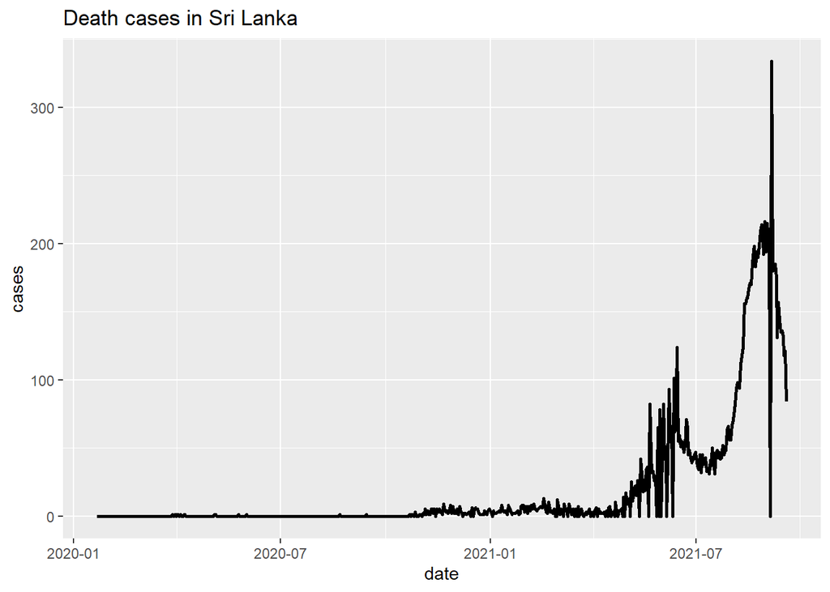

```r
death_cases <- filter(Sri_Lanka_Corona, type == "death")

ggplot(death_cases,aes(date, cases)) + geom_path(size=1) + labs(title = "Death cases in Sri Lanka")
```

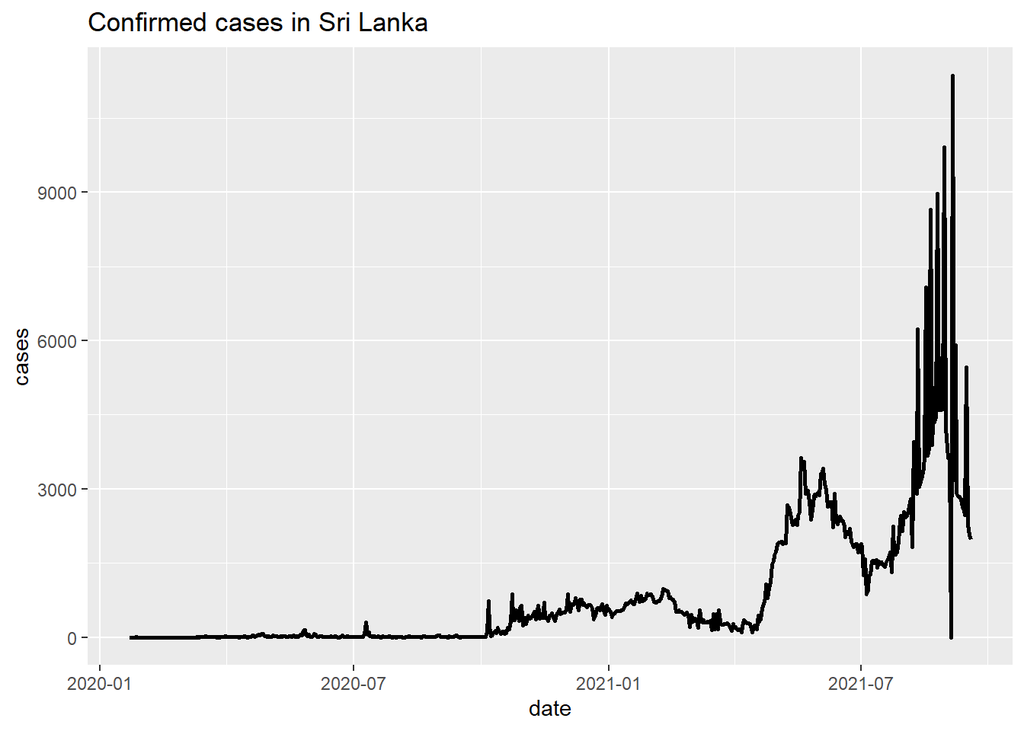

```r
confirmed_cases <- filter(Sri_Lanka_Corona, type == "confirmed")

ggplot(confirmed_cases,aes(x=date,y=cases)) + geom_path(size=1) + labs(title = "Confirmed cases in Sri Lanka")
```

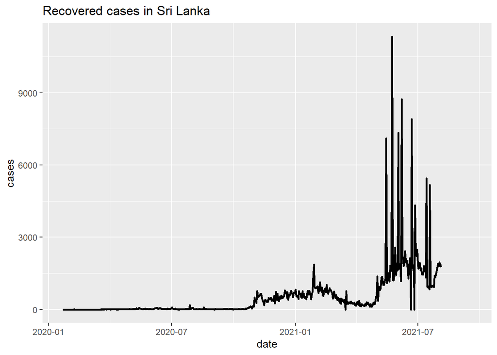

```r
recovered_cases <- filter(Sri_Lanka_Corona, type == "recovered")

ggplot(recovered_cases, aes(date, cases)) + geom_path(size=1) + labs(title = "Recovered cases in Sri Lanka")
```

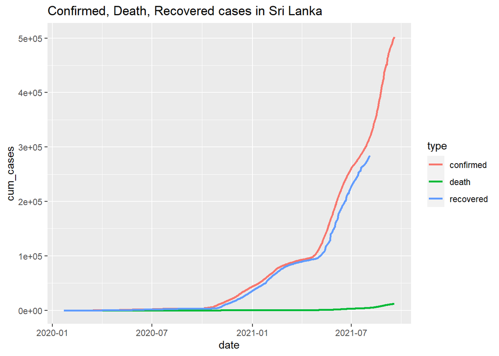

```r
Sri_Lanka_Corona <-  Sri_Lanka_Corona%>%
  group_by(type)%>%
  mutate(cum_cases = cumsum(cases))

ggplot(Sri_Lanka_Corona, aes(date, cum_cases, colour = type)) + geom_path(size = 1) +
  labs(title = "Confirmed, Death, Recovered cases in Sri Lanka")
```

### Comparison with other countries

**Neighbour Countries for Sri Lanka**

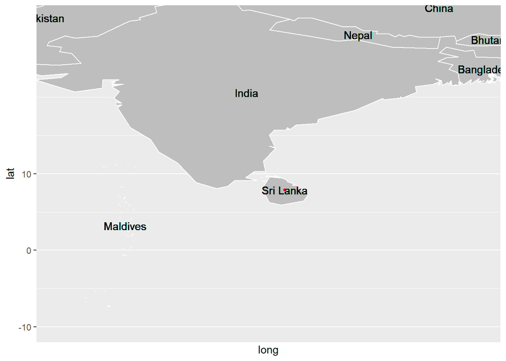

```r
coronavirus <- as.data.frame(coronavirus)

data(wrld_simpl)

p <- ggplot() +
  geom_polygon(
    data = wrld_simpl,
    aes(x = long, y = lat, group = group,), fill = "gray", colour = "white"
  ) +
  coord_cartesian(xlim = c(70, 90), ylim = c(-10, 30)) +
  scale_x_continuous(breaks = seq(-120, 0,20)) +
  scale_y_continuous(breaks = seq(-70,10,10))
p +
  geom_point(
    data = Sri_Lanka_Corona , aes(x = long, y = lat), color = "red", size
    = 1
  )  + geom_text(aes(x=coronavirus$long, y=coronavirus$lat, label=coronavirus$country))
```

**List of Neighbour Countries for Sri Lanka**

```r
neighbourcountries <- subset.data.frame(coronavirus, ( -10< lat & lat < 30) & (70 < long & long < 90) )

count(neighbourcountries,country)
```

```
##     country    n
## 1     India 1818
## 2  Maldives 1818
## 3     Nepal 1818
## 4 Sri Lanka 1818
```

India, Maldives and Nepal are the most near countries for Sri Lanka.

```r
other_countries <- filter(coronavirus, country == "India"|country =="Maldives"|country =="Nepal"|  country =="Sri Lanka")
count(other_countries,country)
```

```
##     country    n
## 1     India 1818
## 2  Maldives 1818
## 3     Nepal 1818
## 4 Sri Lanka 1818
```

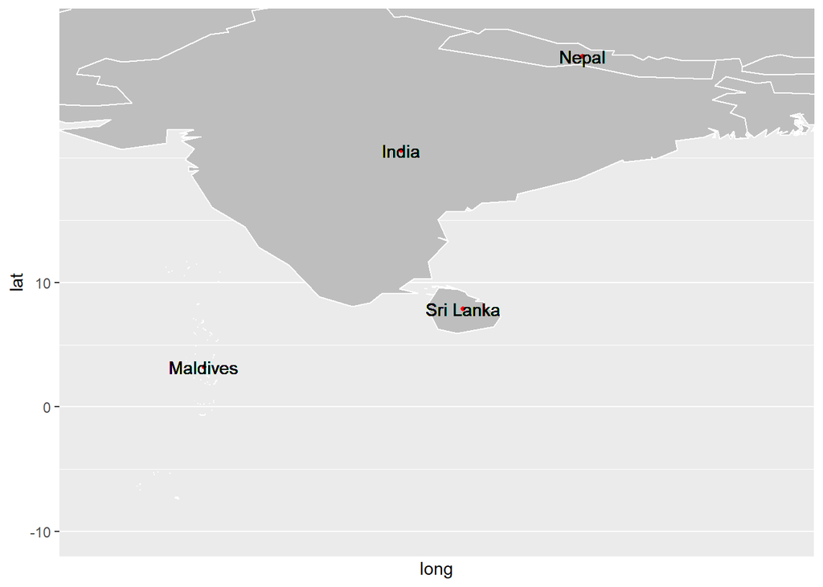

```r
p +
  geom_point(
    data = other_countries , aes(x = long, y = lat), color = "red", size
    = 1
  )  + geom_text(aes(x=other_countries$long, y=other_countries$lat, label=other_countries$country))
```

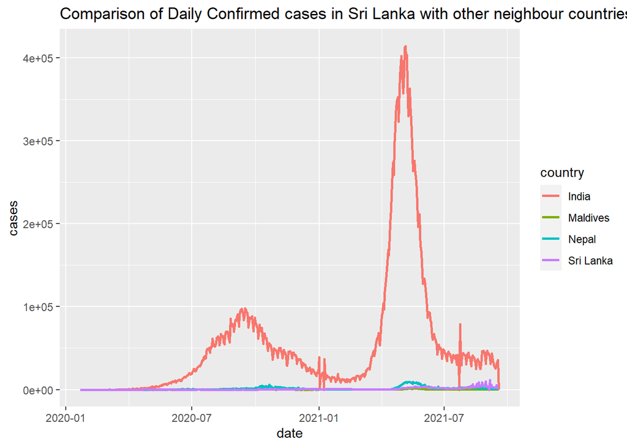

```r
confirmed_other_countries <- filter(other_countries, type == "confirmed")
death_other_countries <- filter(other_countries, type == "death")
recovered_other_countries <- filter(other_countries, type == "recovered")

ggplot(confirmed_other_countries, aes(x = date, y = cases, colour = country)) + geom_path(size=1) +
  labs(title="Comparison of Daily Confirmed cases in Sri Lanka with other neighbour countries")
```

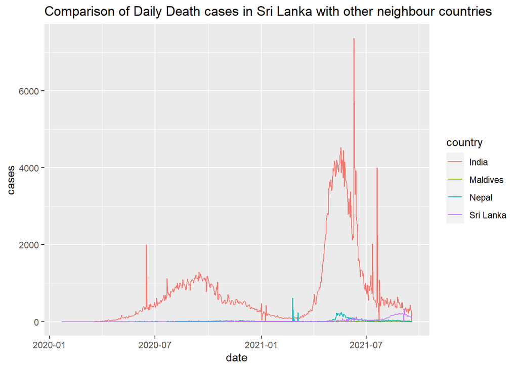

```r
ggplot(death_other_countries, aes(x = date, y = cases, colour = country)) + geom_path(size=0.5) +
  labs(title="Comparison of Daily Death cases in Sri Lanka with other neighbour countries")
```

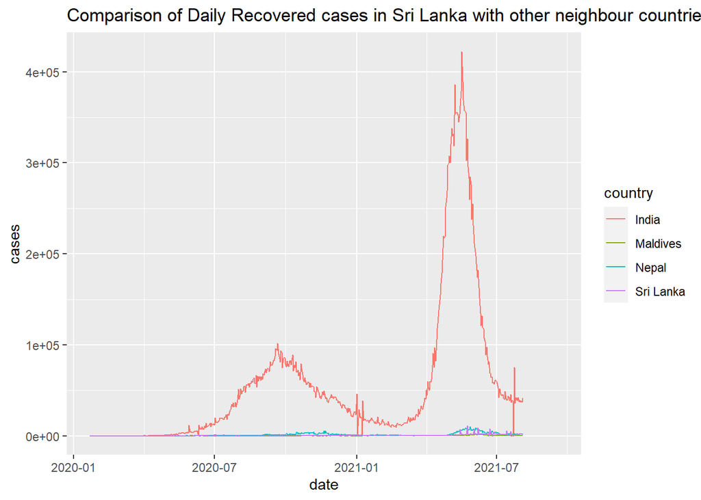

```r
ggplot(recovered_other_countries, aes(x = date, y = cases, colour = country)) + geom_path(size=0.5) +
  labs(title="Comparison of Daily Recovered cases in Sri Lanka with other neighbour countries")
```

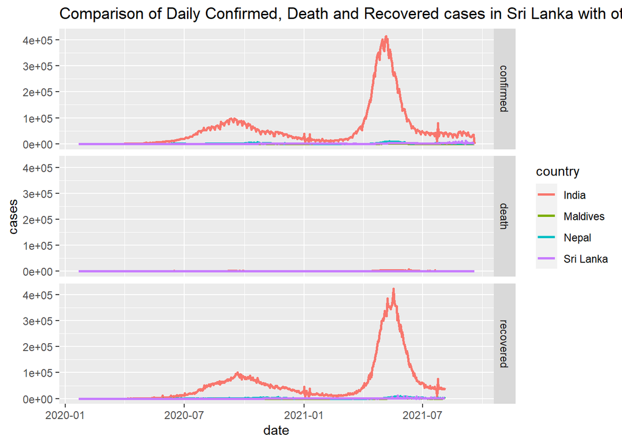

```r
ggplot(other_countries, aes(date, cases,colour = country)) + geom_path(size=1) + facet_grid(rows= vars(type)) +
  labs(title="Comparison of Daily Confirmed, Death and Recovered cases in Sri Lanka with other neighbour countries")
```

## Conclusions and Discussion

The government of Sri Lanka has implemented control measures. Those are island wide curfew, interdistrict travel restriction, and lockdown of high-risk villages to reduce the growth rate of the coronavirus.

## References

https://www.hindawi.com/journals/jam/2020/2954519/

https://www.worldtravelguide.net/guides/asia/sri-lanka/weather-climate-geography/#

https://www.worldbank.org/en/results/2020/10/21/sri-lanka-covid-19-response-saving-lives-today-preparing-for-tomorrow

# —-AS2018335—-